# TP 1: Regresión ordinal. Ejercicio 11 (bonus)

Nicolás Celie, Martín Peralta, Nicolás Ian Rozenberg

2025-06-08

```r
library(tidyverse)
library(cmdstanr)
library(rsample)
library(ggplot2)
library(glue)
```

## Ejercicio 11

Para este ejercicio, en vez de la biblioteca `rstan` vamos a utilizar `cmdstanr`, que es una interfaz de Stan para R equivalente, debido a problemas en la instalación de la primera. Ahora, tenemos la libertad de elegir la distribución que queramos directamente para los parámetros. En este caso, eligiremos en primer lugar priors que no funcionarían para el caso de la pregunta Q30, para el coeficiente $\beta$, donde se vio una relación débilmente decreciente entre la edad y la respuesta. Estas son una normal de media $1000$ y varianza $1$, y una de media $100$ y varianza $1$. Luego, se ajustará con tres priors normales centrados en $0$, pero con varianzas distintas. El prior se los puntos de corte $\theta_i$ se fijará en una normal estándar. Decidimos hacer un submuestreo a 5000 observaciones estratificado, para que la corrida de MCMC sea más rápida.

```r
# Cargamos los datos

df <- read.csv2("./data/data.csv", sep="\t") %>%
  as.data.frame()

Q1 <- quantile(df$age, 0.25, na.rm = TRUE)
Q3 <- quantile(df$age, 0.75, na.rm = TRUE)
IQR <- Q3 - Q1

limite_inferior <- Q1 - 1.5 * IQR
limite_superior <- Q3 + 1.5 * IQR

nrow(df %>%
       filter(age>limite_superior | age<limite_inferior)
)
```

```
## [1] 29110
```

```r
df <- df %>%
  filter(age<limite_superior & age>limite_inferior)

# Filtramos respuestas válidas
df_filtered <- df %>%
  filter(Q30 != 0)

# Subsample estratificado
set.seed(123)
df_strat <- df_filtered %>%
  group_by(Q30) %>%
  sample_frac(size = 5000 / nrow(df_filtered)) %>%
  ungroup()
```

```r
create_ordinal_regression_stan <- function(prior_beta, prior_theta){
  ordinal_regression_stan <- glue("
  data {{
    int<lower=0> N; // Cantidad de observaciones
    array[N] int<lower=1, upper=5> y;
    array[N] real x;
  }}
  parameters {{
    vector[1] beta;
    ordered[4] theta; // 4 puntos de corte
  }}
  model {{
    beta ~ {prior_beta};
    theta ~ {prior_theta}; // Todos los thetas tienen el mismo prior
    for (n in 1:N)
      y[n] ~ ordered_logistic(x[n] * beta[1], theta);
  }}
  ")
  ordinal_regression_stan
}

prior_beta_muy_alejado <- "normal(1000, 1)"
prior_beta_alejado <- "normal(100, 1)"
prior_beta_centrado_fuerte <- "normal(0, 0.001)"
prior_beta_centrado_moderado<- "normal(0,1)"
prior_beta_centrado_debil <- "normal(0, 5)"
prior_theta <- "normal(0,1)"


# Lista de priors
priors_beta <- list(
  "Normal(1000,1)" = prior_beta_muy_alejado,
  "Normal(100,1)" = prior_beta_alejado,
  "Normal(0,0.001)" = prior_beta_centrado_fuerte,
  "Normal(0,1)" = prior_beta_centrado_moderado,
  "Normal(0,5)" = prior_beta_centrado_debil
)

# Definimos la lista de datos para Stan
data_list <- list(
  N = nrow(df_strat),
  y = df_strat$Q30,
  x = as.numeric(df_strat[["age"]])
)


posterior_betas <- data.frame()

for (i in seq_along(priors_beta)) {
  prior_name <- names(priors_beta)[i]
  prior_code <- priors_beta[[i]]

  print(paste("Ajustando modelo con prior:", prior_name))

  code <- create_ordinal_regression_stan(prior_code, prior_theta)
  f <- write_stan_file(
    code,
    basename = NULL,
    force_overwrite = FALSE,
    hash_salt = ""
  )

  mod <- cmdstan_model(f)
  fit <- mod$sample(data = data_list, seed = 123, num_samples=300, num_warmup=150, num_chains=1, cores=4)

  beta_samples <- fit$draws("beta", format = "df")
  beta_df <- data.frame(beta = beta_samples$`beta[1]`, prior = prior_name)

  posterior_betas <- rbind(posterior_betas, beta_df)
}
```

Graficamos las distribuciones a posteriori

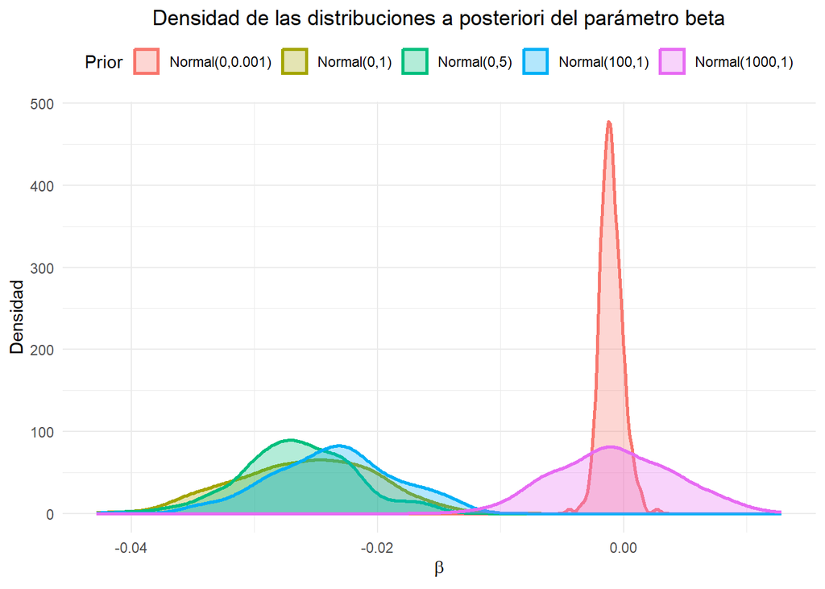

```r
ggplot(posterior_betas, aes(x = beta, fill = prior, color = prior)) +
  geom_density(alpha = 0.3, size = 1) +
  theme_minimal() +
  labs(
    title = "Densidad de las distribuciones a posteriori del parámetro beta",
    x = expression(beta),
    y = "Densidad",
    fill = "Prior",
    color = "Prior"
  ) +
  theme(
    plot.title = element_text(hjust = 0.5),
    legend.position = "top"
  )
```